# Exploring immune responses to i.v. BCG and protection from subsequent Mtb Challenge

## Data

This 2024 TB Hackday script uses data from two related studies:

1. [Darrah et al. 2023](https://pubmed.ncbi.nlm.nih.gov/37267955/) (Cell Host Microbe) **Airway T cells are a correlate of i.v. Bacille Calmette-Guerin-mediated protection against tuberculosis in rhesus macaques**
2. [Liu et al. 2023](https://pmc.ncbi.nlm.nih.gov/articles/PMC10394165/) (*Cell Reports)* **Blood transcriptional correlates of BCG-induced protection against tuberculosis in rhesus macaques**

## Background

Liu et al. 2023 immunized 34 monkeys intravenously (i.v.) with different doses of the bacteria Bacillus Calmette-Guérin (BCG). After 24 weeks, the animals were then challenged with Mycobacterium tuberculosis (Mtb). Blood drawn from these monkeys and Bronchoalveolar lavages (BALs) were then evaluated by Darrah et al. 2023.

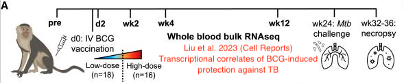

Liu et al. 2023 Cell Reports Time Points

## Setup R

Load relevant packages. Change <data_dir> variable as appropriate.

```r
require(tibble)
require(dplyr)
require(readr)
require(ggplot2)
data_dir = '/home/processed_data'
data_dir = 'data'
```

## Load Data

Load relevant data tables.

```r
gex_tbl = readr::read_tsv(file.path(data_dir,"liu_etal_counts.csv"))
rmeta_tbl = readr::read_csv(file.path(data_dir,"liu_etal_metadata.csv"))
rmeta_tbl <- column_to_rownames(as.data.frame(rmeta_tbl), var = "sampleid")
correlates_tbl = readr::read_csv(file.path(data_dir, "darrah_dose_immune_markers.csv"))
correlates_tbl = correlates_tbl %>% rename(animalid = subjid)
```

Table Descriptions

1. The `gex_tbl` table contains normalized gene expression data, which will be explored in other modules. However, not that the column names contain two parts X_Y, where X is animal identifier (e.g. 13N02, A11V075) and Y is time point of the blood draw prior to the challenge (e.g., d2Pre, wk2Pre, wk4Pre, wk12Pre, see above). These time points are shown in the panel above.
2. The `rmeta_tbl` table contains information about the IV BCG dose received, whether the monkey was protected from TB challenge, and the number of granulomas present in the lung after challenge. Below we bin monkeys by BCG dose similar to Liu et al.
3. The `correlates_tbl` table contains data published as part of Darrah et al. 2023 study. It includes immunological measures for all of the animal identifiers included in the `gex_table`. The data came from [zenodo repository](https://zenodo.org/records/7855102) where a number of immunological measures were obtained from peripheral PBMCs, blood, and Bronchoalveolar lavage (BAL). These data include ex vivo T cell responses, blood work (e.g., GLUCOSE, CHOLERSTEROL, WBC) , as well as some antibody data.

## Joining endpoint with immunological correlates

The protection endpoint is contained in the `rmeta_tbl` table. Check to see if you agree with the authors assertion that higher i.v BCG dose was associated with protection status. Were any of the low dose animals protected?

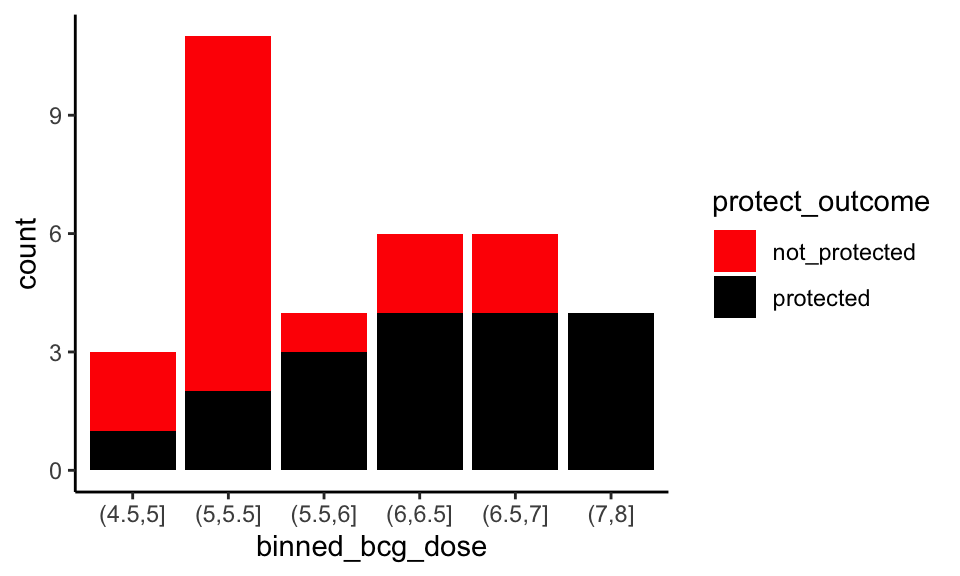

```r
rmeta_tbl$binned_bcg_dose= rmeta_tbl$bcg_dose_log10 %>% cut(., breaks = c(4.5,5,5.5,6.0, 6.5, 7, 8))
rmeta_tbl %>%
  group_by(binned_bcg_dose, animalid, protect_outcome) %>%
  filter(Study == "Dose") %>% # only consider the Dose study, where route is consistently i.v. BCG
  slice(1) %>% # This ensure one row per animal, avoids double counting
  ggplot(., aes(x = binned_bcg_dose , fill = protect_outcome) ) +
  geom_bar( ) +
  theme_classic()+
  scale_fill_manual(values = c("red","black"))
```

## Figure 1D

As a first exploration, consider Figure 1D from Liu et al. 2023. It show the number of cytokine producing CD4 and CD8 T cells sampled from the lungs via BAL (y-axis) versus i.v. BCG dose (x-axis). The median response is shown by the bold colored lines.

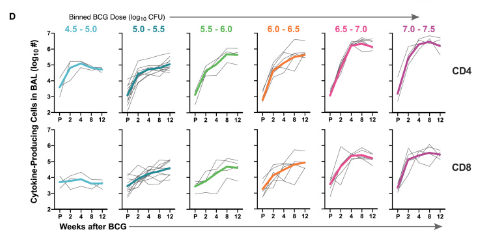

Figure 1D from Liu et al. 2023

The immune correlates data `correlates_tbl` has a `<key>` column and `<short_key>` column.

IMPORTANT NOTE: the `<key>` column includes time point or “nAUC”, whereas the short_key column does not. If you filter by `<short_key>` column you will return data from all time points, which is what we want for figure 1!!!

The variables names are terse. For the `<short_key>`, the authors use abbreviations for cytokines in : G (IFNg) , T (TNF) , 2 (IL-2), 17 (IL-17). They use “Any” to indicate positivity for cytokine. For BAL (lung), the relevant short key names for CD4 and CD8 T cells producing any of the 4 cytokines is: `(L)#CD4:AnyG2T17` and `(L)#CD8:AnyG2T17` , respectively.

Run the code below to reproduce the figure:

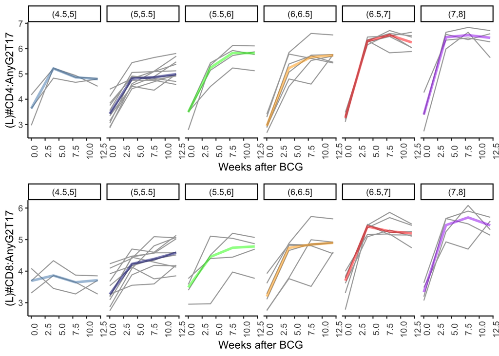

```r
# DEFINE A FUNCTION FOR PLOTTING BY DOSE GROUP SIMILAR TO FIGURE 1D
response_by_dose_plot <- function(var1 = "(L)#CD4:AnyG2T17") {
  # Select data based on short_key match to <var1>
  selected_var1 =   correlates_tbl %>%
    filter(short_key == var1) %>%
    filter(tp != "nAUC")
  # Construct data1 by joining metadata to selected data,
  # note we group_by subject, and dose bin so we only have one
  # row per animal.
  data1 = rmeta_tbl %>%
    filter(Study == "Dose") %>%
    group_by(binned_bcg_dose, animalid, protect_outcome) %>%
    tally() %>%
    left_join(selected_var1)
  # We compute the median at each time point for each binned group
  # to show central trend similar to Fig 1D.
  data_median1 = data1 %>%
    group_by(binned_bcg_dose, tp) %>%
    summarise( value = median(value))
  # Use ggplot to construct the plot
  gg = ggplot(data = data1,
         aes(x = as.numeric(tp) , y = value)) +
    geom_line(aes(group= animalid), col = "darkgray") +
    geom_line(data = data_median1,
              aes(group = binned_bcg_dose, col = binned_bcg_dose),
              size = 1.2, alpha = .5) +
    facet_wrap(~binned_bcg_dose, nrow= 1) +
    ylab(var1) +
    xlab("Weeks after BCG") +
    theme_classic()+
    theme(legend.position = "none")+
    theme(axis.text.x = element_text(angle = 90))+
    scale_color_manual(values = c("steelblue", "navy","green","orange", "red","purple"))
  return(gg)
}

# USE TEH FUNCITON ON TWO RELEVANT VARIABLES
gg1 =  response_by_dose_plot(var1 = "(L)#CD4:AnyG2T17")
gg2 =  response_by_dose_plot(var1 = "(L)#CD8:AnyG2T17")
gridExtra::grid.arrange(gg1, gg2, ncol =1)
```

### Examine other variables

Explore the variables in the correlates_tbl. Use `%>%` to tether operations in R. Apply the dplyr `group_by` and `slice` commands to remove duplicate values. The `select` the variable you care about.

```r
correlates_tbl %>%
  dplyr::group_by(short_key) %>%
  dplyr::slice(1) %>%
  dplyr::select(short_key, key, tissue, antigen, unit)
```

```
# A tibble: 209 × 5
# Groups:   short_key [209]
   short_key         key                          tissue       antigen unit
   <chr>             <chr>                        <chr>        <chr>   <chr>
 1 (L)#B             Lg+ B 0                      (L)ung = BAL None    Number
 2 (L)#CD4           Lg+ CD4 0                    (L)ung = BAL None    Number
 3 (L)#CD4:17        Lg+ Marginal/CD4/IL17 Abs 0  (L)ung = BAL PPD     Number
 4 (L)#CD4:2         Lg+ Marginal/CD4/IL2 Abs 0   (L)ung = BAL PPD     Number
 5 (L)#CD4:21        Lg+ Marginal/CD4/IL21 Abs 0  (L)ung = BAL PPD     Number
 6 (L)#CD4:AnyG2T17  Lg+ Any/CD4/g2T17 Abs 0      (L)ung = BAL PPD     Number
 7 (L)#CD4:G         Lg+ Marginal/CD4/IFNg Abs 0  (L)ung = BAL PPD     Number
 8 (L)#CD4:G+2+17+T+ Lg+ Bool/CD4 Abs/g+2+17+T+ 0 (L)ung = BAL PPD     Number
 9 (L)#CD4:G+2+17-T+ Lg+ Bool/CD4 Abs/g+2+17-T+ 0 (L)ung = BAL PPD     Number
10 (L)#CD4:G+2+17-T- Lg+ Bool/CD4 Abs/g+2+17-T- 0 (L)ung = BAL PPD     Number
# ℹ 199 more rows
```

NOTE: the `<key>` column includes time point (e.g., 0, 2, 4, 8, 12 weeks) or “nAUC”, whereas the `<short_key.` column does not. If you filter by `<short_key>` column you will return data from all time points.

### Try this:

Filter to only items in the lung (i.e. containing `(L)` in the `<short_key>` column, using the `filter` command.

```r
correlates_tbl %>%
  dplyr::group_by(short_key) %>%
  dplyr::slice(1) %>%
  dplyr::select(short_key, key, tissue, antigen, unit) %>%
  dplyr::filter(stringr::str_detect(pattern = "(L)", string = short_key))
```

```
# A tibble: 90 × 5
# Groups:   short_key [90]
   short_key         key                          tissue       antigen unit
   <chr>             <chr>                        <chr>        <chr>   <chr>
 1 (L)#B             Lg+ B 0                      (L)ung = BAL None    Number
 2 (L)#CD4           Lg+ CD4 0                    (L)ung = BAL None    Number
 3 (L)#CD4:17        Lg+ Marginal/CD4/IL17 Abs 0  (L)ung = BAL PPD     Number
 4 (L)#CD4:2         Lg+ Marginal/CD4/IL2 Abs 0   (L)ung = BAL PPD     Number
 5 (L)#CD4:21        Lg+ Marginal/CD4/IL21 Abs 0  (L)ung = BAL PPD     Number
 6 (L)#CD4:AnyG2T17  Lg+ Any/CD4/g2T17 Abs 0      (L)ung = BAL PPD     Number
 7 (L)#CD4:G         Lg+ Marginal/CD4/IFNg Abs 0  (L)ung = BAL PPD     Number
 8 (L)#CD4:G+2+17+T+ Lg+ Bool/CD4 Abs/g+2+17+T+ 0 (L)ung = BAL PPD     Number
 9 (L)#CD4:G+2+17-T+ Lg+ Bool/CD4 Abs/g+2+17-T+ 0 (L)ung = BAL PPD     Number
10 (L)#CD4:G+2+17-T- Lg+ Bool/CD4 Abs/g+2+17-T- 0 (L)ung = BAL PPD     Number
# ℹ 80 more rows
```

Filter to only items in the lung (i.e. containing `(L)`in the `<short_key>` column, using the `filter` command. Further filter to “Bool” type combination using `filter` command on the `<key>` column. Filter to only CD4+ and IFNg + subsets (`G+`). Limit to % instead of raw counts.

```r
correlates_tbl %>%
  dplyr::group_by(short_key) %>%
  dplyr::slice(1) %>%
  dplyr::select(short_key, key, tissue, antigen, unit) %>%
  dplyr::filter(stringr::str_detect(pattern = "CD4", string = short_key)) %>%
  dplyr::filter(stringr::str_detect(pattern = "(L)", string = short_key)) %>%
  dplyr::filter(stringr::str_detect(pattern = "Bool", string = key))  %>%
  dplyr::filter(stringr::str_detect(pattern = "G+", string = short_key)) %>%
  dplyr::filter(stringr::str_detect(pattern = "%", string = short_key))
```

```
# A tibble: 10 × 5
# Groups:   short_key [10]
   short_key         key                      tissue       antigen unit
   <chr>             <chr>                    <chr>        <chr>   <chr>
 1 (L)%CD4:G+2+17+T+ Bool/CD4/FoP/g+2+17+T+ 0 (L)ung = BAL PPD     Percent
 2 (L)%CD4:G+2+17-T+ Bool/CD4/FoP/g+2+17-T+ 0 (L)ung = BAL PPD     Percent
 3 (L)%CD4:G+2+17-T- Bool/CD4/FoP/g+2+17-T- 0 (L)ung = BAL PPD     Percent
 4 (L)%CD4:G+2-17+T+ Bool/CD4/FoP/g+2-17+T+ 0 (L)ung = BAL PPD     Percent
 5 (L)%CD4:G+2-17-T+ Bool/CD4/FoP/g+2-17-T+ 0 (L)ung = BAL PPD     Percent
 6 (L)%CD4:G+2-17-T- Bool/CD4/FoP/g+2-17-T- 0 (L)ung = BAL PPD     Percent
 7 (L)%CD4:G-2+17-T+ Bool/CD4/FoP/g-2+17-T+ 0 (L)ung = BAL PPD     Percent
 8 (L)%CD4:G-2-17+T+ Bool/CD4/FoP/g-2-17+T+ 0 (L)ung = BAL PPD     Percent
 9 (L)%CD4:G-2-17+T- Bool/CD4/FoP/g-2-17+T- 0 (L)ung = BAL PPD     Percent
10 (L)%CD4:G-2-17-T+ Bool/CD4/FoP/g-2-17-T+ 0 (L)ung = BAL PPD     Percent
```

### Try this: reuse the code with different variables

With the same code you can explore any of the 100s of variables in the data set. Explore more the variable in `correlates_tbl` columns and use `<short_key>` to interrogate more variables.

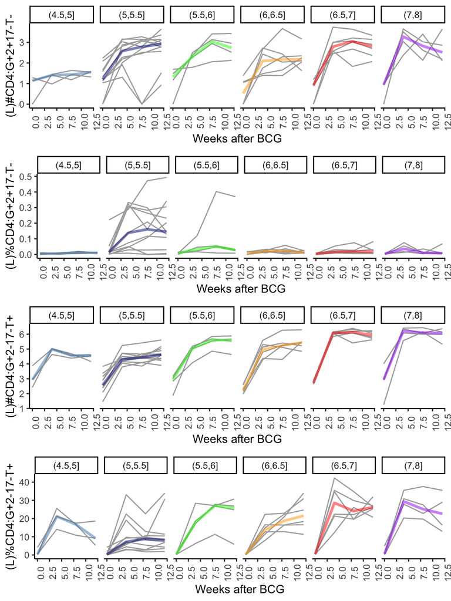

Reuse the code with Different Variables

```r
gg1 =  response_by_dose_plot(var1 = "(L)#CD4:G+2+17-T-")
gg2 =  response_by_dose_plot(var1 = "(L)%CD4:G+2+17-T-")
gg3 =  response_by_dose_plot(var1 = "(L)#CD4:G+2-17-T+")
gg4 =  response_by_dose_plot(var1 = "(L)%CD4:G+2-17-T+")
gridExtra::grid.arrange(gg1, gg2, gg3, gg4, ncol =1)
```

### Visualize longitudinal responses and protection status

Next, let’s extend the code to examine which animal were protected by coloring each line by the animal protection status after TB challenge. (NOTE: Recall the time series was collected after i.v. administration of the BCG vaccine before the challenge).

Run the code. What do you notices about the intermediate dose group? Do those with more robust T cell responses to BCG (i.e., more cytokine producing cells) tend to be protected from subsequent challenge. (In case you are curious – the T cell response is measured *ex vivo* via an intercellular cytokine staining assays where PBMCs were stimulated using a tuberculin protein [PPD skin test antigen](https://www.ncbi.nlm.nih.gov/books/NBK556037/)).

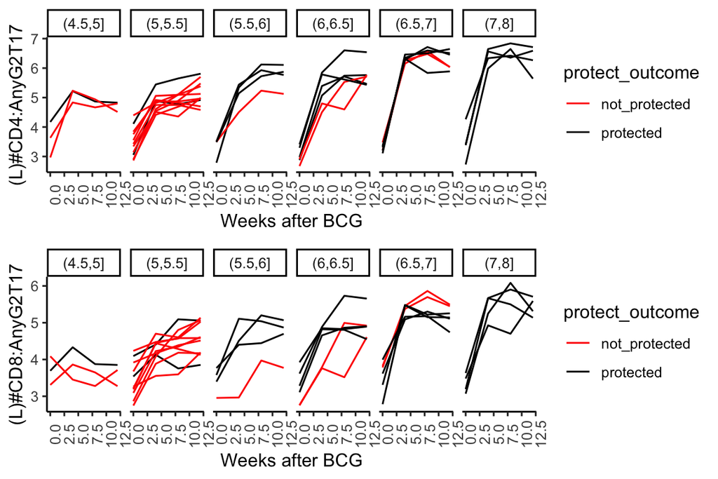

```r
response_by_dose_protection_plot<- function(var1 = "(L)#CD4:AnyG2T17") {
  # Select data based on short_key match to <var1>
  selected_var1 =   correlates_tbl %>%
    filter(short_key == var1) %>%
    filter(tp != "nAUC")
  # Construct data1 by joining metadata to selected data,
  # note we group_by subject, and dose bin so we only have one
  # row per animal.
  data1 = rmeta_tbl %>%
    group_by(binned_bcg_dose, animalid, protect_outcome) %>%
    tally() %>%
    left_join(selected_var1)
  # We compute the median at each time point for each binned group
  # to show central trend similar to Fig 1D.
  # Use ggplot to construct the plot
  gg = ggplot(data = data1,
         aes(x = as.numeric(tp) , y = value)) +
    geom_line(aes(group= animalid, col = protect_outcome)) +
    facet_wrap(~binned_bcg_dose, nrow= 1) +
    ylab(var1) +
    xlab("Weeks after BCG") +
    theme_classic()+
    #theme(legend.position = "none")+
    theme(axis.text.x = element_text(angle = 90))+
    scale_color_manual(values = c("red","black"))
  return(gg)
}

gg1 =  response_by_dose_protection_plot(var1 = "(L)#CD4:AnyG2T17")
gg2 =  response_by_dose_protection_plot(var1 = "(L)#CD8:AnyG2T17")
gridExtra::grid.arrange(gg1, gg2, ncol =1)
```

### Try this

Change the code above to examine other variables. Try “`(L)%CD4:G+2+17-T-"` and `"(L)%CD4:G+2-17-T+"` . What do you notice?

## Data mining for potential associations with protection

Perhaps you wish to examine every variable at once. Below are functions for performing Wilcoxon tests and computing mean and median differences, which we will apply to a large set of variables.

```r
# Function returns p-value from Wilcoxon unpaired test - the likelihood that that rank difference between groups might arise by chance.
test_function <- function(df){
  if (any(is.na(df$value))){
    return(NA)
  }else{
    df$prot = df$protect_outcome == "protected"
    wt = wilcox.test(value~prot, data = df)
    return(wt$p.value)
  }
}

# Function for returning mean and median difference between groups split on protected status
diff_function <- function(df, output = "mean"){
  df$prot = df$protect_outcome == "protected"
  x = df %>%
    group_by(prot) %>%
    summarise(
      mean_value = mean(value, na.rm = TRUE),
      median_value = median(value, na.rm = TRUE)
    ) %>%
    summarise(
      mean_difference = diff(mean_value),
      median_difference = diff(median_value),
      mean_ratio = mean_value[prot == TRUE] / mean_value[prot == FALSE],
      median_ratio = median_value[prot == TRUE] / median_value[prot == FALSE]
    )
  return(x)
}
```

## Compute group differences for every variable

Here we tether together the `group_by` , `group_split` and `purrr::map` to apply `test_function()` and `diff_function()` across each group split.

```r
x = rmeta_tbl %>%
  group_by(animalid, protect_outcome) %>%
  tally() %>%
  select(animalid, protect_outcome) %>%
  left_join(correlates_tbl, by = c("animalid"))

xs = x %>%
  group_by(key) %>%
  group_split()

diff_function(xs[[1]])#[['mean_ratio']]
```

```
# A tibble: 1 × 4
  mean_difference median_difference mean_ratio median_ratio
            <dbl>             <dbl>      <dbl>        <dbl>
1         -0.0563            -0.100      0.987        0.977
```

```r
diffs               = xs %>% purrr::map_dfr(.,~diff_function(.x))
diffs$wilcox_p      = xs %>% purrr::map_dbl(.,~test_function(.x))
diffs$variable_name = xs %>% purrr::map_chr(.,~.x[['key']][1])

key_extra = correlates_tbl %>% group_by(key) %>% slice(1) %>%
  select(key, short_key, tissue, unit, tp)

diffs_tbl = diffs %>% left_join(key_extra, by = c("variable_name" = "key"))
```

## Create volcano style plots

Generate plots show that show the -log10 p-values from Wilcoxon tests (comparing protected and unprotected groups) on the y-axis and the group difference on the x-axis. Points high and to the right are more likely to be significantly associated with protection. Points high and to the left are more associated with risk. Notice that we facet wrap by tissue source (i.e., Lung vs. Periphery) and by time point. What do blue points to the right suggest? *What might the red points at time point week 0 (i.e., baseline) suggest?*

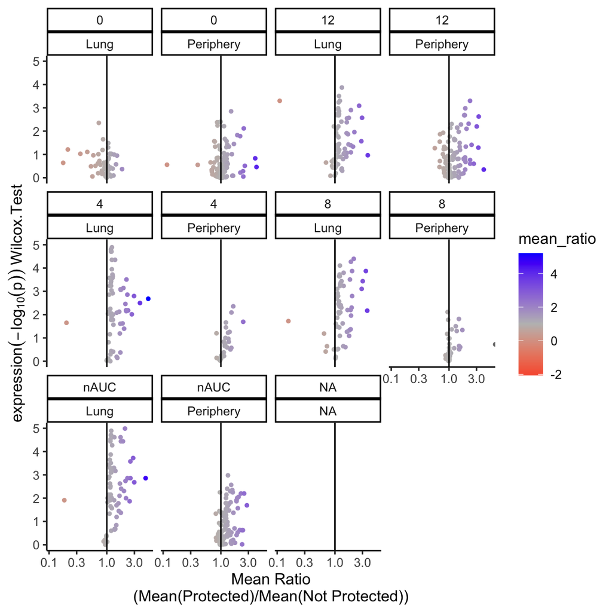

```r
diffs_tbl %>%
  mutate(tissue2 = ifelse(stringr::str_detect(pattern = "ung", string = tissue),
                          "Lung", "Periphery")) %>%
  ggplot(aes(x = mean_ratio, y = -1*log10(wilcox_p)))+
  geom_point(pch = 20, aes(col = mean_ratio)) +
  theme_classic()+
  scale_x_log10() +
  geom_vline(aes(xintercept = 1)) +
  xlab("Mean Ratio\n(Mean(Protected)/Mean(Not Protected))")+
  ylab(expression(-log[10](p))~ Wilcox.Test)  +
  facet_wrap(tp~tissue2)+
  scale_color_gradient2(
    low = "red",       # Color for values below 1
    mid = "gray",     # Neutral color at 1
    high = "blue",     # Color for values above 1
    midpoint = 1       # Center the gradient at 1
  )
```

### Sort the results to find the variables that distinguish the protected and non-protected groups.

Try sorting diffs_tbl to find parameters that differ between the protected and non protected groups.

You may wish to :

- `filter(tp = 0)` to filter to the pre-BCG time point
- `arrange(wilcox_p)` to sort by p-value
- `arrange(mean_ratio)` to sort by mean_ratio

## Baseline a variable associated with risk

If you find a variable you wish to compare, you can make a box plot like this

```
var_name =  "YOUR VARIABLE"
diffs_tbl %>% filter(key == var_name ) %>%
  ggplot(aes(x=protect_outcome, y = value)) +
  geom_boxplot() +
  geom_point() +
  ggpubr::stat_compare_means() +
  ylab(var_name ) +
  theme_classic()
```

## Try this: Examine variable and protection status longitudinally

You can also use the `response_by_dose_protection_plot((var1 = "YOUR_VARIABLE")` function we used above to examine values of an immune variable longitudinally.

# Suggestions

```r
diffs_tbl %>%
  mutate(tissue2 = ifelse(stringr::str_detect(pattern = "ung", string = tissue),
                          "Lung", "Periphery")) %>%
  filter(tp == 8) %>%
  arrange(wilcox_p) %>%
  select(short_key, variable_name, mean_ratio, wilcox_p, tissue2, tp )
```

```
# A tibble: 161 × 6
   short_key         variable_name             mean_ratio wilcox_p tissue2 tp
   <chr>             <chr>                          <dbl>    <dbl> <chr>   <chr>
 1 (L)%CD4:G+2-17-T+ Bool/CD4/FoP/g+2-17-T+ 8        2.12  4.02e-5 Lung    8
 2 (L)%CD4:G         Marginal/CD4/IFNg/FoP 8         1.89  5.38e-5 Lung    8
 3 (L)#CD4:G+2-17-T+ Lg+ Bool/CD4 Abs/g+2-17-…       1.22  7.83e-5 Lung    8
 4 (L)%CD4:G+2-17+T+ Bool/CD4/FoP/g+2-17+T+ 8        3.43  1.34e-4 Lung    8
 5 (L)%CD4:T         Marginal/CD4/TNF/FoP 8          1.98  1.34e-4 Lung    8
 6 (L)#CD4:G-2-17+T+ Lg+ Bool/CD4 Abs/g-2-17+…       1.41  1.60e-4 Lung    8
 7 (L)#CD4:T         Lg+ Marginal/CD4/TNF Abs…       1.20  1.90e-4 Lung    8
 8 (L)#CD4:AnyG2T17  Lg+ Any/CD4/g2T17 Abs 8         1.18  2.25e-4 Lung    8
 9 (L)#CD4:G-2-17-T+ Lg+ Bool/CD4 Abs/g-2-17-…       1.21  2.25e-4 Lung    8
10 (L)#CD4:G         Lg+ Marginal/CD4/IFNg Ab…       1.19  2.25e-4 Lung    8
# ℹ 151 more rows
```

In other modules you will be able to consider which gene expression modules might correlate with these immunological measures.

## Joining Data by Subject

Suppose you want to evaluate gene expression with a specific immune variable. Suppose you select `Bool/CD4/FoP/g+2-17-T+ 8` This is from the BAL and Boolean combination of CD4 T cells that are IFNg+ IL2- IL17- and TNF+ at time point 8.

```r
var1 = 'Bool/CD4/FoP/g+2-17-T+ 8'
# Extract the data for a single variable
selected_var1 =   correlates_tbl %>%
  filter(key == var1) %>%
  select(animalid, key, short_key, value)

# join the metadata with the immunological variable by animalid
# create a sampleid that matched the gex_tbl sample names
data1 = rmeta_tbl %>%
  left_join(selected_var1, by= "animalid" )  %>%
  mutate(sample_id = paste0(animalid, "_",visit,"Pre" )) %>%
  select(sample_id, key, short_key, value)
# samples not linked
names(gex_tbl)[!names(gex_tbl) %in% data1$sample_id]
```

```
[1] "gene,0NR_65,0NR_66,0NR_67,0NR_68,0TL_113,0TL_114,0TL_115,0TL_116,13N022_d2Pre,13N022_wk12Pre,13N022_wk2Pre,13N022_wk4Pre,13N022_wkm4Pre,13N023_d2Pre,13N023_wk12Pre,13N023_wk2Pre,13N023_wk4Pre,13N023_wkm4Pre,13N025_d2Pre,13N025_wk12Pre,13N025_wk2Pre,13N025_wk4Pre,13N025_wkm4Pre,13N026_d2Pre,13N0…
```

```r
# samples linkable
names(gex_tbl)[names(gex_tbl) %in% data1$sample_id]
```

```
character(0)
```

## Background Notes

### Darrah et al. 2023 Graphical Abstract

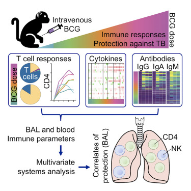

### Liu et al. 2023 Graphical Abstract

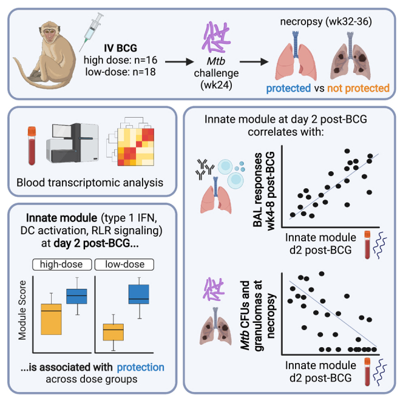

1. [Darrah et al. 2020](https://www.nature.com/articles/s41586-019-1817-8) (*Nature*) **Prevention of tuberculosis in macaques after intravenous BCG immunization.**
2. [Darrah et al. 2023](https://pubmed.ncbi.nlm.nih.gov/37267955/) (Cell Host Microbe) **Airway T cells are a correlate of i.v. Bacille Calmette-Guerin-mediated protection against tuberculosis in rhesus macaques**
3. [Liu et al. 2023](https://pmc.ncbi.nlm.nih.gov/articles/PMC10394165/) (*Cell Reports)* **Blood transcriptional correlates of BCG-induced protection against tuberculosis in rhesus macaques**